# QC For The Very Curious

Study Notes for [QC for the very curious](https://quantum.country/qcvc)

Jay (notetaker)

last updated on: 2021-10-31

# 1 The state of a qubit

The state of a qubit is a vector in a two-dimensional vector space. This vector space is known as state space.

1. a qubit has a state;
2. much like a bit, that state is an abstract mathematical object; but
3. whereas a bit’s abstract state is a number, 0 or 1, the state of a qubit is a 2-dimensional vector;
4. we call the 2-dimensional vector space where states live state space.

## 1.1 Connecting qubits to bits: the computational basis states

There are two special quantum states which correspond to the 0 and 1 states of a classical bit.

The notateion with $|$ and $\rangle$ is called the *ket* notation.

$$|0 \rangle :=
\begin{bmatrix}
1\\
0
\end{bmatrix},$$

$$|1 \rangle :=
\begin{bmatrix}
0\\
1
\end{bmatrix}.$$

A quantum computer can manipulate $|0 \rangle$ or $|1 \rangle$ in ways very similar to how a conventional computer can manipulate 0 or 1.

These special states $|0 \rangle$ and $|1 \rangle$ are *computational basis states*.

## 1.2 General state of a qubit

$$\alpha |0 \rangle + \beta |1 \rangle =
\begin{bmatrix}
\alpha \\
\beta
\end{bmatrix},$$

where $\alpha$ and $\beta$ are complex numbers.

*Superposition* simply means linear combination.

A state like the above is a *superposition* of $|0 \rangle$ and $|1 \rangle$. $\alpha$ and $\beta$ are called amplitudes. The normalization constraint for them is

$$|\alpha|^2 + |\beta|^2 = 1.$$

Summing up: **the quantum state of a qubit is a vector of unit length in a two-dimensional complex vector space known as state space.**

Things to ponder: What does the quantum state mean? Why is it a vector in a complex vector space?

# 2 Introducing quantum logic gates

A quantum logic gate is simply a way of manipulating quantum information, that is, the quantum state of a qubit or a collection of qubits.

They’re analogous to the classical logic gates used in ordinary, everyday computers – gates such as the AND, OR, and NOT gates.

## 2.1 The quantum NOT gate

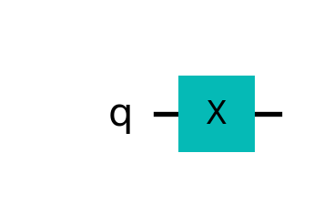

quantum NOT gate circuit diagram (q is the input qubit, the X rectangle is the NOT gate, and the two lines are quantum wires)

$$X(\alpha |0 \rangle + \beta |1 \rangle) = \alpha |1 \rangle + \beta |0 \rangle$$

Matrix representation:

$$X =
\begin{bmatrix}
0 & 1 \\
1 & 0
\end{bmatrix}.$$

## 2.2 The Hadamard gate

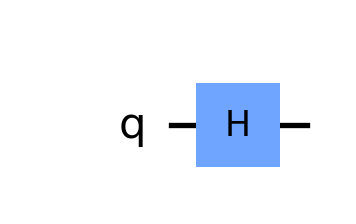

quantum Hadamard gate circuit diagram

$$H |0\rangle = \frac{|0\rangle + |1\rangle}{\sqrt{2}} \\
H |1\rangle = \frac{|0\rangle - |1\rangle}{\sqrt{2}} \\
H (\alpha |0\rangle + \beta |1\rangle) =
\frac{\alpha + \beta}{\sqrt{2}}|0\rangle + \frac{\alpha - \beta}{\sqrt{2}}|1\rangle$$

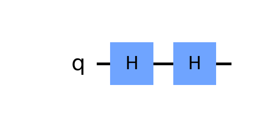

the net effect of two quantum Hadamard gates is the same as a quantum wire

Matrix representation:

$$H = \frac{1}{\sqrt{2}}
\begin{bmatrix}
1 & 1 \\
1 & -1
\end{bmatrix}.$$

$$HH = I$$

The matrix representation of Hadamard $H$ has some special properties.

1. It is **Hermitian**, i.e., it is equal to its conjugate transpose.

$H^{\dagger} := (H^{T})^*$, where the superscript $^T$ denotes transpose and $^*$ conjugation operation.

$$H=H^\dagger$$

2. It is **unitary**, i.e., its inverse is equal to its conjugate transpose.
   $$H^{-1}=H^\dagger,\,or\;
   HH^\dagger=H^{\dagger}H=I$$
3. As a consequence of the above two properties, it is also **involutory**, i.e., its square is equal to the identity matrix.
   $$H^2=I$$

Put them together, $H^2=HH=HH^\dagger=H^{\dagger}H=I$.

## 2.3 Mesuring a qubit

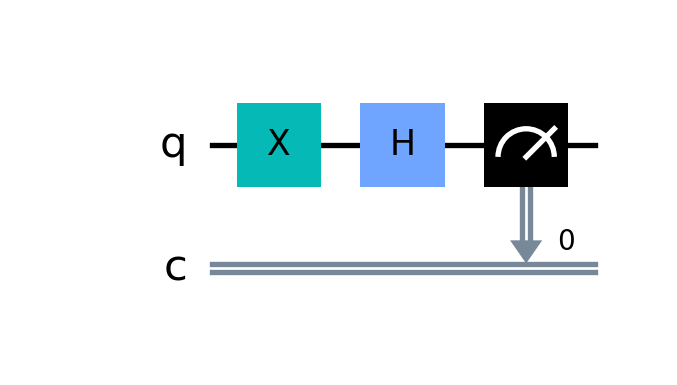

The meter symbol represents a measurement in computational basis. The double wire indicates a classical bit going off.

The quantum state of any state is not directly observable. That is, given a single qubit with a state $\alpha|0\rangle+\beta|1\rangle$, there is no way to figure out $\alpha$ and $\beta$ if they start out unknown.

If you measure a qubit with state $\alpha|0\rangle+\beta|1\rangle$ in the computational basis, then the outcome is a classical bit: either 0, with probability $|\alpha|^2$, or 1 with probability $|\beta|^2$. The corresponding state of the qubit after measurement is $|0\rangle$ or $|1\rangle$.

*Note that you don’t get the value of $\alpha$ or $\beta$, or otherwise you could store lots of classical bits in the binary expansion of the real component of $\alpha$ and extract it later.*

By combining computational basis measurements with quantum gates like the Hadamard and NOT (and other) gates, it’s possible to simulate arbitrary quantum measurements.

## 2.4 General single-qubit gates

A general single-qubit gate can be represented as a $2×2$ unitary matrix, $U$. A matrix $U$ is unitary if $U^{\dagger} U = I$, where $U^{\dagger} := (U^{T})^*$

*All gates are unitary.* They preserve length. Unitary matrix is the only class of matrix that preserve length.

Two more gates.

1. Pauli Y gate.
   $$Y :=
   \begin{bmatrix}
   0 & -i \\
   i & 0
   \end{bmatrix}, \\
   Y |0\rangle = i|1\rangle; \quad Y |1\rangle = -i|0\rangle.$$
2. Pauli Z gate.
   $$Z :=
   \begin{bmatrix}
   1 & 0 \\
   0 & -1
   \end{bmatrix}, \\
   Z |0\rangle = |0\rangle; \quad Z |1\rangle = -|1\rangle.$$

## 2.5 The controlled-NOT gate

A two-qubit system. Four computational basis states: $|00\rangle$, $|01\rangle$, $|10\rangle$, and $|11\rangle$.

We can have superpositions of the four computational basis states.

$$\alpha|00\rangle + \beta|01\rangle + \gamma|10\rangle + \delta|011\rangle$$
The amplitute $\alpha$, $\beta$, $\gamma$, and $\delta$ are complex numbers and $|\alpha|^2 + |\beta|^2 + |\gamma|^2 + |\delta|^2 = 1$.

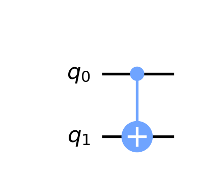

$q_0$ is the controlled qubit, and $q_1$ is target qubit.

Now the CNOT gate: if the controlled qubit is set to 1, then it flips the target qubit, and otherwise it does nothing.

$$|00\rangle \rightarrow |00\rangle \\
|01\rangle \rightarrow |01\rangle \\
|10\rangle \rightarrow |11\rangle \\
|11\rangle \rightarrow |10\rangle$$
Let $x$ and $y$ be classical bits, i.e., 0 or 1. The above can be written as

$$|x, y\rangle \rightarrow |x, y\oplus x\rangle.$$
We can use a CNOT gate to construct an *entangled state*. An entanglement is a property of composite quantum system where the joint state cannot be written as a product of states of its component systems.

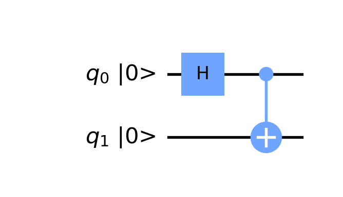

Construct an entangled state.

Consider a two-qubit system as shown in the margin diagram. The $|00\rangle$ state is a two-qubit input. It becomes $\frac{|00\rangle + |10\rangle}{\sqrt(2)}$ after going through the Hadamard gate, and $\frac{|00\rangle + |11\rangle}{\sqrt(2)}$ after the CNOT gate.

This combined state (also known as one of the Bell states) $\frac{1}{\sqrt(2)}(|00\rangle + |11\rangle)$ is entangled. It cannot be written as two separate qubit states, which has interesting implications. Although the two qubits are in superposition, measuring one will tell us the state of the other and collapse its superposition. For example, if we measured the first qubit and got the state |1⟩, the collective state of our qubits changes like so:

$$\frac{1}{\sqrt(2)}(|00\rangle + |11\rangle) \xrightarrow{measurement} |11\rangle.$$

Even if we separated these qubits light-years away, measuring one qubit collapses the superposition and appears to have an immediate effect on the other. This is the [“spooky action at a distance”](https://en.wikipedia.org/wiki/Quantum_nonlocality) that upset so many physicists in the early 20th century.

When viewed only in the computational basis ${|0\rangle, |1\rangle}$, the behaviour of the CNOT gate appears to be like the equivalent classical gate. However, the simplicity of labelling one qubit the control and the other the target does not reflect the complexity of what happens for most input values of both qubits.

In fact, it’s actually possible for the target qubit to affect the control qubit. Let’s introduce two more single-qubit states: $|+\rangle$, and $|-\rangle$.

$$|+\rangle = \frac{|0\rangle + |1\rangle}{\sqrt(2)} \\
|-\rangle = \frac{|0\rangle - |1\rangle}{\sqrt(2)}$$
These two states are Hadamard transformed basis. Applying CNOT gate to the corresponding basis of a 2-qubit system gives the following.

$$|++\rangle \rightarrow |++\rangle \\
|+-\rangle \rightarrow |--\rangle \\
|-+\rangle \rightarrow |-+\rangle \\
|--\rangle \rightarrow |+-\rangle$$
Viewing CNOT in this basis, the state of the second qubit remains unchanged, and the state of the first qubit is flipped, according to the state of the second bit.

Let’s verify one of them, the second one.

$$\begin{align}
|+-\rangle &= |+\rangle \oplus |-\rangle \\
&= (\frac{|0\rangle + |1\rangle}{\sqrt(2)}) \oplus (\frac{|0\rangle - |1\rangle}{\sqrt(2)}) \\
&= \frac{1}{2}(|00\rangle - |01\rangle + |10\rangle - |11\rangle) \\
\end{align}$$
Applying CNOT gate, we get

$$\begin{align}
CNOT(|+-\rangle)
&= \frac{1}{2}(|00\rangle - |01\rangle + |11\rangle - |10\rangle) \\
&= (\frac{|0\rangle - |1\rangle}{\sqrt(2)}) \oplus (\frac{|0\rangle - |1\rangle}{\sqrt(2)}) \\
&= |-\rangle \oplus |-\rangle \\
&= |--\rangle
\end{align}$$

# 3 Universal quantum computing

# 4 Appendix

## 4.1 Bloch Sphere

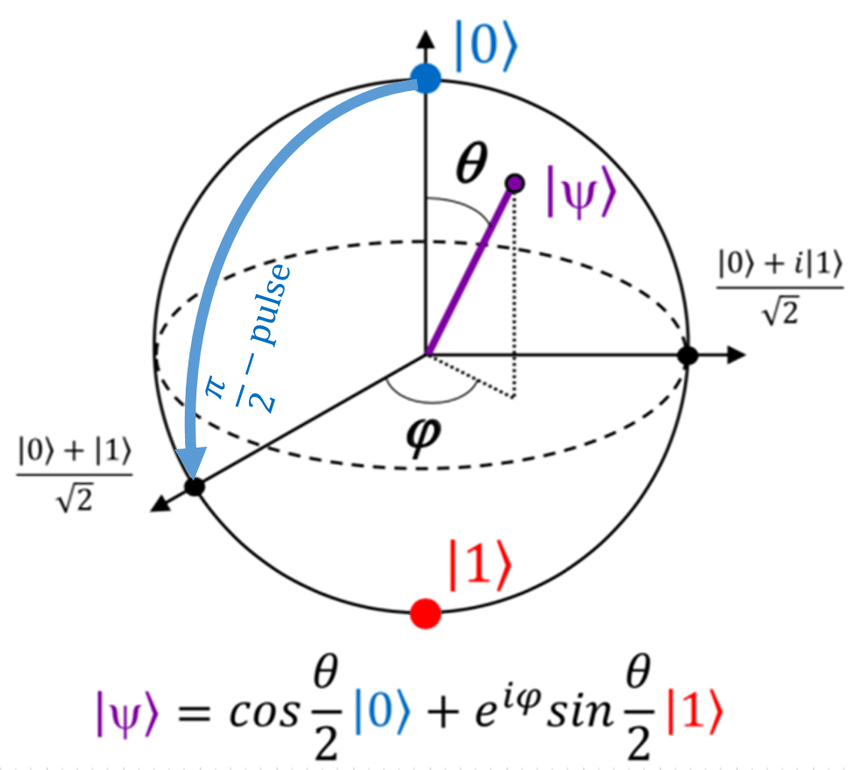

The Bloch sphere.

Visualize 2D complex vector space in a 3D sphere.

The state of any qubit can be written in the following form.

$$|\psi\rangle = \cos\frac{\theta}{2}|0\rangle + \sin\frac{\theta}{2}e^{i\phi}|1\rangle \\
0 < \theta < \pi; \quad 0 < \phi < 2\pi$$
Why is it the case?

$$\begin{align}
|\psi\rangle &= \alpha |0\rangle + \beta |1\rangle \quad\quad (\alpha,\beta \in \mathbb C; \quad |\alpha|^2 + |\beta|^2 =1) \\
&= r_0 e^{i\phi_0} |0\rangle + r_1 e^{i\phi_1} |1\rangle \quad\quad (r_0, r_1 \in \mathbb R; \quad r_0^2 + r_1^2 = 1) \\
&= e^{i\phi_0} (r_0 |0\rangle + r_1 e^{i(\phi_1 - \phi_0)} |1\rangle) \\
& = \cos\frac{\theta}{2}|0\rangle + \sin\frac{\theta}{2}e^{i\phi}|1\rangle \quad (\text{drop the global phase, and re-param.})
\end{align}$$

Recall that any complex number $z$ can be expressed in exponential form and polar form.
$$z=re^{i\theta}=r(\cos\theta+i\sin\theta)$$

Z-basis:

$$|0\rangle =
\begin{bmatrix}
1\\
0
\end{bmatrix} \\
|1\rangle =
\begin{bmatrix}
0\\
1
\end{bmatrix}$$

X-basis:

$$|+\rangle = \frac{1}{\sqrt{2}}(|0\rangle+|1\rangle) = \frac{1}{\sqrt{2}}
\begin{bmatrix}
1\\
1
\end{bmatrix} \\
|-\rangle = \frac{1}{\sqrt{2}}(|0\rangle-|1\rangle) = \frac{1}{\sqrt{2}}
\begin{bmatrix}
1\\
-1
\end{bmatrix}$$

Y-basis:

$$|\circlearrowleft\rangle = \frac{1}{\sqrt{2}}(|0\rangle+i|1\rangle) = \frac{1}{\sqrt{2}}
\begin{bmatrix}
1\\
i
\end{bmatrix} \\\\
|\circlearrowright\rangle = \frac{1}{\sqrt{2}}(|0\rangle-i|1\rangle) = \frac{1}{\sqrt{2}}
\begin{bmatrix}
1\\
-i
\end{bmatrix}$$

## 4.2 Global Phase

In general, we refer to any overall factor $\gamma$ on a state for which $|\gamma|^2=1$ as a “global phase.”

States that differ only by a global phase are physically indistinguishable. Why? To find the probability of measuring $|x\rangle$, we take the inner product of $|x\rangle$ and the state we are measuring, $\gamma|\psi\rangle$.

$$|\langle x| ( \gamma |\psi\rangle) |^2 = | \gamma \langle x|\psi\rangle|^2 = |\langle x|\psi\rangle|^2$$